# Selecting & Filtering by Attributes; More Plotting

This time, we'll work a little more on manipulating and exploring the attributes. This is akin to working with the attribute table in desktop GIS software.

Start by importing pandas, geopandas, matplotlib.pyplot, and os:

```
>>> import pandas as pd
>>> import geopandas as gpd
>>> import matplotlib.pyplot as plt
>>> import os
```

```python
import pandas as pd
import geopandas as gpd
import matplotlib.pyplot as plt
import os
```

##### Important! Reset your working directory to your home folder, and only run this once!

```
>>> os.chdir('../')
>>> os.getcwd()
```

```python
os.chdir('../')
os.getcwd()
```

```
'/home/jupyter-phwh9568'
```

#### Import the OSMP_Trails shapefile as trails:

```
>>> trails = gpd.read_file('Data/OSMP_Trails.shp')
```

```python
trails = gpd.read_file('Data/OSMP_Trails.shp')
```

#### Use .head() to view only the first few rows of the dataframe:

```
>>> trails.head()
```

```python
trails.head()
```

|  | OBJECTID | OWNER | BICYCLES | DISPLAY | TRAILTYPE | DATEFROM | DATETO | SEGMENTID | HORSES | RID | TRLID | MILEAGE | MEASUREDFE | TRAILNAME | SHAPELEN | GLOBALID | geometry |
| --- | --- | --- | --- | --- | --- | --- | --- | --- | --- | --- | --- | --- | --- | --- | --- | --- | --- |
| 0 | 2568 | OSMP | No | Yes | Hiking Trail | 2005-12-31T00:00:00.000Z | 2099-12-31T00:00:00.000Z | 296-357-356 | No | 1000 | 296 | 0.106 | -9999.0 | Boulder Falls | 562.147648 | {118369E0-68A9-4089-8B04-295FBCA62CBB} | LINESTRING (-105.40585 40.00468, -105.40606 40... |
| 1 | 2569 | OSMP | Yes | Yes | Multi-Use Trail | 2016-10-26T00:00:00.000Z | 2099-12-31T00:00:00.000Z | 116-424-421 | Yes | 1135 | 116 | 0.876 | -9999.0 | Flatirons Vista North | 4625.547170 | {FCFF5BB0-A953-4151-AA12-FB5EFD7B7C22} | LINESTRING (-105.23878 39.92365, -105.23881 39... |
| 2 | 2570 | OSMP | Yes | Yes | Multi-Use Trail | 2016-10-25T00:00:00.000Z | 2099-12-31T00:00:00.000Z | 116-430-428 | Yes | 1140 | 116 | 0.019 | -9999.0 | Flatirons Vista North | 102.623588 | {A2917E15-8708-416C-8694-8A3E0871855B} | LINESTRING (-105.23569 39.92407, -105.23570 39... |
| 3 | 2571 | OSMP | Yes | Yes | Multi-Use Trail | 2016-10-25T00:00:00.000Z | 2099-12-31T00:00:00.000Z | 116-425-424 | Yes | 1544 | 116 | 0.178 | -9999.0 | Flatirons Vista North | 939.742819 | {64EA49F9-8293-4859-AD3E-05244C78CAEB} | LINESTRING (-105.23655 39.92554, -105.23660 39... |
| 4 | 2572 | OSMP | Yes | Yes | Multi-Use Trail | 2016-10-25T00:00:00.000Z | 2099-12-31T00:00:00.000Z | 117-429-428 | Yes | 1141 | 117 | 0.004 | -9999.0 | Prairie Vista | 22.315176 | {BE8E1241-78E1-4F43-9EA0-968591282E6D} | LINESTRING (-105.23555 39.92430, -105.23556 39... |

#### You can also view all column headers:

```
>>> trails.columns
```

```python
trails.columns
```

```
Index(['OBJECTID', 'OWNER', 'BICYCLES', 'DISPLAY', 'TRAILTYPE', 'DATEFROM',
       'DATETO', 'SEGMENTID', 'HORSES', 'RID', 'TRLID', 'MILEAGE',
       'MEASUREDFE', 'TRAILNAME', 'SHAPELEN', 'GLOBALID', 'geometry'],
      dtype='object')
```

#### You can also call up just one column:

```
>>> trails.TRAILTYPE
```

```python
trails.TRAILTYPE
```

```
0         Hiking Trail
1      Multi-Use Trail
2      Multi-Use Trail
3      Multi-Use Trail
4      Multi-Use Trail
            ...
574       Hiking Trail
575       Hiking Trail
576       Hiking Trail
577       Hiking Trail
578       Hiking Trail
Name: TRAILTYPE, Length: 579, dtype: object
```

#### Now take a look at the trail data by plotting it:

```
>>> trails.plot()
```

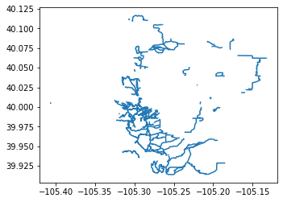

```python
trails.plot()
```

#### You can also filter by attributes and create a new variable from the result:

```
>>> bikeTrails = trails.loc[trails['BICYCLES']=='Yes']
>>> bikeTrails
```

```python
bikeTrails = trails.loc[trails['BICYCLES']=='Yes']
bikeTrails
```

|  | OBJECTID | OWNER | BICYCLES | DISPLAY | TRAILTYPE | DATEFROM | DATETO | SEGMENTID | HORSES | RID | TRLID | MILEAGE | MEASUREDFE | TRAILNAME | SHAPELEN | GLOBALID | geometry |
| --- | --- | --- | --- | --- | --- | --- | --- | --- | --- | --- | --- | --- | --- | --- | --- | --- | --- |
| 1 | 2569 | OSMP | Yes | Yes | Multi-Use Trail | 2016-10-26T00:00:00.000Z | 2099-12-31T00:00:00.000Z | 116-424-421 | Yes | 1135 | 116 | 0.876 | -9999.0 | Flatirons Vista North | 4625.547170 | {FCFF5BB0-A953-4151-AA12-FB5EFD7B7C22} | LINESTRING (-105.23878 39.92365, -105.23881 39... |
| 2 | 2570 | OSMP | Yes | Yes | Multi-Use Trail | 2016-10-25T00:00:00.000Z | 2099-12-31T00:00:00.000Z | 116-430-428 | Yes | 1140 | 116 | 0.019 | -9999.0 | Flatirons Vista North | 102.623588 | {A2917E15-8708-416C-8694-8A3E0871855B} | LINESTRING (-105.23569 39.92407, -105.23570 39... |
| 3 | 2571 | OSMP | Yes | Yes | Multi-Use Trail | 2016-10-25T00:00:00.000Z | 2099-12-31T00:00:00.000Z | 116-425-424 | Yes | 1544 | 116 | 0.178 | -9999.0 | Flatirons Vista North | 939.742819 | {64EA49F9-8293-4859-AD3E-05244C78CAEB} | LINESTRING (-105.23655 39.92554, -105.23660 39... |
| 4 | 2572 | OSMP | Yes | Yes | Multi-Use Trail | 2016-10-25T00:00:00.000Z | 2099-12-31T00:00:00.000Z | 117-429-428 | Yes | 1141 | 117 | 0.004 | -9999.0 | Prairie Vista | 22.315176 | {BE8E1241-78E1-4F43-9EA0-968591282E6D} | LINESTRING (-105.23555 39.92430, -105.23556 39... |
| 5 | 2573 | OSMP | Yes | Yes | Multi-Use Trail | 2016-10-25T00:00:00.000Z | 2099-12-31T00:00:00.000Z | 117-427-423 | Yes | 1545 | 117 | 0.199 | -9999.0 | Prairie Vista | 1049.725608 | {74B9B1A6-1368-4BA2-9A6A-9106F7C56135} | LINESTRING (-105.23563 39.92439, -105.23563 39... |
| ... | ... | ... | ... | ... | ... | ... | ... | ... | ... | ... | ... | ... | ... | ... | ... | ... | ... |
| 443 | 3370 | OSMP | Yes | Yes | Multi-Use Trail | 2015-04-09T00:00:00.000Z | 2099-12-31T00:00:00.000Z | 403-622-674 | Yes | 1592 | 403 | 0.032 | 138.0 | Foothills South | 166.390898 | {2004BF80-764B-4277-B81A-D50A331C634A} | LINESTRING (-105.28883 40.06240, -105.28883 40... |
| 459 | 3387 | OSMP | Yes | Yes | Multi-Use Trail | 2019-06-20T00:00:00.000Z | 2099-12-31T00:00:00.000Z | 403-618-621 | Yes | 1694 | 403 | 0.219 | NaN | Foothills South | 1157.710963 | {9C7A1C42-0A4B-4F9E-84F7-166C8FE38FD5} | LINESTRING (-105.29140 40.06012, -105.29138 40... |
| 460 | 3388 | OSMP | Yes | Yes | Multi-Use Trail | 2019-06-20T00:00:00.000Z | 2099-12-31T00:00:00.000Z | 403-617-618 | Yes | 1695 | 403 | 0.072 | NaN | Foothills South | 378.164900 | {457AD6EC-A830-40C5-89FF-1C531C78C487} | LINESTRING (-105.29144 40.05908, -105.29144 40... |
| 461 | 3389 | OSMP | Yes | Yes | Multi-Use Trail | 2019-06-20T00:00:00.000Z | 2099-12-31T00:00:00.000Z | 403-615-617 | Yes | 1696 | 403 | 0.452 | NaN | Foothills South | 2388.989417 | {36D74C83-7AB4-4328-ACF6-1BE2D9E0B6C9} | LINESTRING (-105.29247 40.05301, -105.29247 40... |
| 481 | 3409 | OSMP | Yes | Yes | Multi-Use Trail | 2019-07-10T00:00:00.000Z | 2099-12-31T00:00:00.000Z | 112-434-433 | Yes | 1708 | 112 | 2.667 | NaN | High Plains | 14083.727879 | {E6F13C70-97C3-44A2-BB61-784FC0FE9628} | LINESTRING (-105.20617 39.91431, -105.20617 39... |

130 rows × 17 columns

#### Nice. You have a new geodataframe that is just bike trails. Plot them:

```
>>> bikeTrails.plot()
```

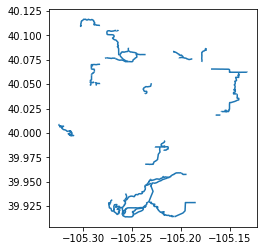

```python
bikeTrails.plot()
```

#### Now, do the same for hiking trails, then count the results:

```
>>> hikeTrails = trails.loc[trails['TRAILTYPE']=='Hiking Trail']
>>> len(hikeTrails)
```

```python
hikeTrails = trails.loc[trails['TRAILTYPE']=='Hiking Trail']
len(hikeTrails)
```

```
439
```

#### Do the same for horse trails:

```
>>> horseTrails = trails.loc[trails['HORSES']=='Yes']
>>> len(horseTrails)
```

```python
horseTrails = trails.loc[trails['HORSES']=='Yes']
len(horseTrails)
```

```
467
```

#### Now, select all trails whose mileage is greater than 2 miles:

```
>>> trails.loc[trails['MILEAGE']>=2]
```

```python
trails.loc[trails['MILEAGE']>=2]
```

|  | OBJECTID | OWNER | BICYCLES | DISPLAY | TRAILTYPE | DATEFROM | DATETO | SEGMENTID | HORSES | RID | TRLID | MILEAGE | MEASUREDFE | TRAILNAME | SHAPELEN | GLOBALID | geometry |
| --- | --- | --- | --- | --- | --- | --- | --- | --- | --- | --- | --- | --- | --- | --- | --- | --- | --- |
| 49 | 2922 | OSMP | Yes | Yes | Multi-Use Trail | 2005-12-31T00:00:00.000Z | 2099-12-31T00:00:00.000Z | 408-652-675 | Yes | 1009 | 408 | 2.779 | 14775.0 | Left Hand | 14671.966605 | {24656ACD-CE01-4D16-A322-DB00832F328C} | LINESTRING (-105.26275 40.08011, -105.26276 40... |
| 117 | 2990 | OSMP | Yes | Yes | Multi-Use Trail | 2016-02-01T00:00:00.000Z | 2099-12-31T00:00:00.000Z | 501-537-555 | Yes | 1050 | 501 | 2.227 | 11862.0 | East Boulder - White Rocks | 11758.165168 | {5D08B3D6-5CA7-4B84-A015-F5918D3D8732} | LINESTRING (-105.14279 40.04001, -105.14333 40... |
| 481 | 3409 | OSMP | Yes | Yes | Multi-Use Trail | 2019-07-10T00:00:00.000Z | 2099-12-31T00:00:00.000Z | 112-434-433 | Yes | 1708 | 112 | 2.667 | NaN | High Plains | 14083.727879 | {E6F13C70-97C3-44A2-BB61-784FC0FE9628} | LINESTRING (-105.20617 39.91431, -105.20617 39... |

#### Interesting. Only 3 trails are 2 miles or greater in length?

Not exactly. These are trail segments. Note in the original geodataframe that there are multiple rows with the same trail name.

#### Let's all the unique trail names:

```
>>> trails.TRAILNAME.unique()
```

```python
trails.TRAILNAME.unique()
```

```
array(['Boulder Falls', 'Flatirons Vista North', 'Prairie Vista',
       'Flatirons Vista South', 'Doudy Draw', 'Mount Sanitas', 'Anemone',
       'IBM Connector', 'Cottontail', 'Eldorado Canyon',
       'Green Mountain West Ridge', 'Bear Peak', '7th Street Connector',
       '8th Street Connector', '9th Street Connector', 'Baseline',
       '6th Street Connector West', 'Baseline Connector',
       '6th Street Connector', 'Joder Ranch', 'Buckingham Park',
       'Left Hand', 'Sage', 'North Rim', 'Eagle', 'Mesa Reservoir',
       'Degge', 'Cobalt', 'Hidden Valley', 'Foothills North',
       'Hogback Ridge', 'Foothills South', 'Foothills Spur', 'Old Kiln',
       'Old Kiln Spur', 'Wonderland Lake',
       'Foothills - Wonderland Lake spur', 'Wonderland Hill',
       'East Boulder - Gunbarrel', 'East Boulder - White Rocks',
       'East Boulder - Teller Farm', 'East Boulder - Teller Lake #5',
       'East Boulder - Teller Farm Spur', 'East Boulder - Teller Spur',
       'Sawhill Ponds', 'Cottonwood', 'Sombrero Marsh', 'Dry Creek',
       'Centennial - Equestrian', 'South Boulder Creek', 'Cherryvale',
       'Mayhoffer-Singletree', 'Cowdrey Draw', 'Community Ditch',
       'Marshall Mesa', 'Marshall Valley', 'Coal Seam',
       'Community Ditch Hwy 93 Spur', 'Greenbelt Connector', 'Coalton',
       'Greenbelt Plateau', 'Marshall Valley - Accessible',
       'Doudy Draw Picnic Area', 'Spring Brook Loop North',
       'Spring Brook Loop South', 'Fowler', 'Goshawk Ridge',
       'Doudy Draw Connector', 'Northern Quarry', "Lion's Lair",
       "Lion's Lair Spur", 'Sanitas Valley', 'East Ridge', 'Dakota Ridge',
       'Goat', 'Sanitas Spur', 'Sunshine Canyon', 'Sanitas Connector',
       'Red Rocks', 'Red Rocks Spur', 'Viewpoint', 'Flagstaff',
       'Halfway House', 'Panorama', 'Boy Scout', 'Chapman Drive',
       'Plains Overlook', 'Sensory', 'Tenderfoot', 'Ute', 'Range View',
       'Crown Rock', 'Crown Rock Picnic Loop', 'Sacred Cliffs',
       'Gregory Canyon Spur', 'Green Mountain Summit', 'Bear Canyon',
       'Bear Peak West Ridge', 'Fern Canyon', 'Green Bear',
       'Gregory Canyon', 'Long Canyon', 'Lost Gulch', 'Ranger',
       'Shadow Canyon', 'South Boulder Peak', 'Saddle Rock',
       'E.M. Greenman', 'South Mesa Connector', 'Shadow Canyon North',
       'Shanahan - Mesa', 'Mallory Cave', 'Royal Arch', 'Enchanted Mesa',
       'Enchanted-Kohler Spur', 'Enchanted - McClintock Spur',
       'Four Pines', 'McClintock Lower', 'McClintock Upper', 'Mesa',
       "Wood's Quarry", 'Amphitheater Express', 'Flatirons Loop',
       '1st/2nd Flatiron', 'Amphitheater', 'Baseline-Gregory Connector',
       'Bluebell Mesa', 'Bluebell Road', 'Bluebell Spur',
       'Bluebell-Baird', 'Meadow', 'Ski Jump', 'KOA Lake', 'Artist Point',
       "May's Point", 'NCAR', 'NIST Service Rd Connector', 'Chautauqua',
       'Shadow Canyon South', 'Dunn House Loop', 'NCAR - Bear Connector',
       'High Plains', 'NCAR - Skunk Canyon', 'Kohler Mesa', 'Holly Berry',
       'Skunk Connector', 'Skunk Canyon', 'NIST Service Rd',
       'Kohler Spur', 'Skunk Canyon Spur', 'NCAR - Bear Canyon',
       'Devils Thumb Access', 'Cragmoor Connector', 'South Fork Shanahan',
       'Shanahan Connector', 'North Fork Shanahan',
       'Hardscrabble Connector', 'NCAR - Table Mesa',
       'NCAR - Table Mesa Bear', 'Lehigh Connector - South',
       'Fern Meadow - Cragmoor', 'Greenbriar Connector',
       'Lower Big Bluestem', 'Upper Big Bluestem', 'Bluestem Connector',
       'Shadow Canyon South Spur', 'Homestead', 'Towhee',
       'Mesa Connector', 'South Boulder Creek West',
       'Lehigh Connector - North', 'Big Bluestem West', 'South Mesa Spur',
       'NCAR Water Tank Rd'], dtype=object)
```

#### Find out how many unique trail names there are using the same len()

```
>>> len(trails.TRAILNAME.unique())
```

```python
len(trails.TRAILNAME.unique())
```

```
174
```

#### Now, let's take each row, group them by trail name, then sum up the total mileage of each trail by trail name:

Sounds hard, but not really!

```
>>> trailLengths = trails.groupby('TRAILNAME')['MILEAGE'].sum()
>>> trailLengths
```

```python
trailLengths = trails.groupby('TRAILNAME')['MILEAGE'].sum()
trailLengths
```

```
TRAILNAME
1st/2nd Flatiron             0.852
6th Street Connector         0.283
6th Street Connector West    0.033
7th Street Connector         0.017
8th Street Connector         0.018
                             ...
Ute                          0.776
Viewpoint                    1.112
Wonderland Hill              0.983
Wonderland Lake              1.083
Wood's Quarry                0.399
Name: MILEAGE, Length: 174, dtype: float64
```

#### Resetting the index will bring it into a Pandas dataframe:

```
>>> trailLengths = trailLengths.reset_index()
>>> trailLengths
```

```python
trailLengths = trailLengths.reset_index()
trailLengths
```

|  | TRAILNAME | MILEAGE |
| --- | --- | --- |
| 0 | 1st/2nd Flatiron | 0.852 |
| 1 | 6th Street Connector | 0.283 |
| 2 | 6th Street Connector West | 0.033 |
| 3 | 7th Street Connector | 0.017 |
| 4 | 8th Street Connector | 0.018 |
| ... | ... | ... |
| 169 | Ute | 0.776 |
| 170 | Viewpoint | 1.112 |
| 171 | Wonderland Hill | 0.983 |
| 172 | Wonderland Lake | 1.083 |
| 173 | Wood's Quarry | 0.399 |

174 rows × 2 columns

#### Now you can export your dataframe to a csv:

```
>>> trailLengths.to_csv('trailLengths.csv')
```

```python
trailLengths.to_csv('trailLengths.csv')
```

#### You should find it in your home folder.

#### Now let's do a little more plotting:

Import OSMP.shp and Boulder_Co.shp:

```
>>> osmp = gpd.read_file('Data/OSMP.shp')
>>> county = gpd.read_file('data/Boulder_Co.shp')
```

```python
osmp = gpd.read_file('Data/OSMP.shp')
county = gpd.read_file('Data/Boulder_Co.shp')
```

#### Reset the county layer's crs to match the osmp layer:

```
>>> county = county.to_crs(osmp.crs)
```

```python
county = county.to_crs(osmp.crs)
```

#### To plot more than two layers together, you must use 'fig' and a "blank" axis like so:

```
>>> fig, ax = plt.subplots(1, 1, figsize = (15,15))
>>> county.plot(ax=ax, color = '#F0E68C', edgecolor='black')
>>> osmp.plot(ax=ax, color = 'green', alpha=0.5)
>>> hikeTrails.plot(ax=ax, color='red')
>>> bikeTrails.plot(ax=ax, color='yellow')
```

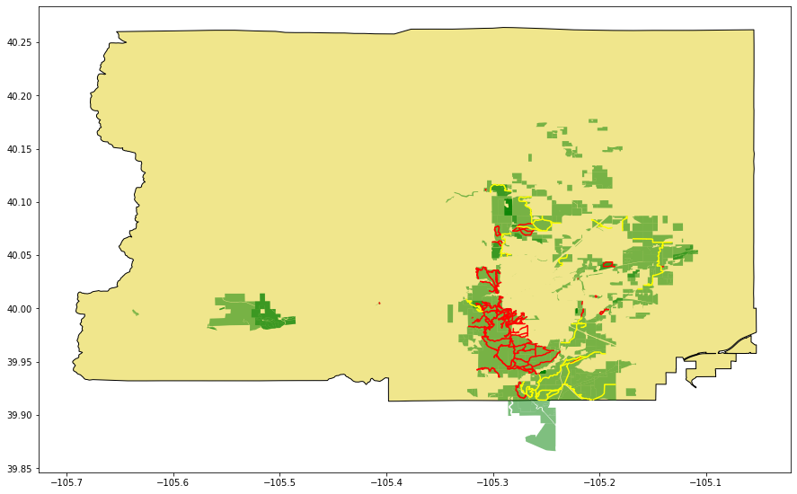

```python
fig, ax = plt.subplots(1, 1, figsize = (15,15))
county.plot(ax=ax, color = '#F0E68C', edgecolor='black')
osmp.plot(ax=ax, color='green', alpha=0.5)
hikeTrails.plot(ax=ax, color='red')
bikeTrails.plot(ax=ax, color='yellow')
```